# Tipps für Übungaufgabe 9

Fabio Votta

31 Januar 2019

### Datensatz einladen

```r
allbus2008 <- read_spss("allbus2008.sav")
```

**AUFGABE: Faktoranalyse mit religiösen und übernatürlichen Überzeugungen**

*V702* KIRCHGANGSHAEUFIGKEIT, MUTTER

*V703* KIRCHGANGSHAEUFIGKEIT, VATER

*V704* KIRCHGANGSHAEUFIGKEIT, BEFR. ALS KIND

*V705* WIE OFT BETEN SIE? <11ER SKALA>

*V706* HAEUFIGKEIT VON KIRCHL.AKTIVITAETEN,BEFR

*V707* RELIGIOESER GEGENSTAND IN HAUSHALT?

*V708* HAEUFIGKEIT: WALLFAHRTEN

*V709* EINSCHAETZUNG EIGENER RELIGIOSITAET

*V710* RELIGIOESER ODER SPIRITUELLER MENSCH?

*V711* WAHRHEITSGEHALT IN RELIGIONEN

*V712* RELIGION HILFT GLUECK + FRIEDEN FINDEN

*V713* RELIGION HILFT FREUNDSCHAFTEN SCHLIESSEN

*V714* RELIGION HILFT TROST ZU FINDEN

*V715* RELIGION HILFT RICHTIGEN LEUTEN BEGEGNEN

*V716* BINDUNG ZUR RELIGION AN LEBENSWENDEPUNKT

*V717* GLUECKSBRINGER BRINGEN MANCHMAL GLUECK

*V718* WAHRSAGER KOENNEN ZUKUNFT VORAUSSEHEN

*V719* WUNDERHEILER HABEN UEBERNATUERL. KRAEFTE

*V720* HOROSKOP HAT EINFLUSS AUF LEBENSVERLAUF

### Erste Herangehensweise

Wir benutzen das Package `psych` um eine PCA durchzuführen. Dazu wählen wir zunächst die relevanten Variablen mit `select` aus und pipen diese dann in den `pca()` Befehl. Da alle gewünschten Variablen nebeneinander stehen müssen wir diese nicht einzeln spezifizieren sondern können diese mit einem *`:`* verbinden.

```r
obl_pca <- allbus2008 %>%
  select(V702:V720) %>%
  pca(rotate = "oblimin")

obl_pca
```

```
## Principal Components Analysis
## Call: principal(r = r, nfactors = nfactors, residuals = residuals,
##     rotate = rotate, n.obs = n.obs, covar = covar, scores = scores,
##     missing = missing, impute = impute, oblique.scores = oblique.scores,
##     method = method)
## Standardized loadings (pattern matrix) based upon correlation matrix
##        PC1    h2   u2 com
## V702 -0.69 0.477 0.52   1
## V703 -0.65 0.419 0.58   1
## V704 -0.68 0.464 0.54   1
## V705 -0.78 0.608 0.39   1
## V706 -0.60 0.355 0.65   1
## V707  0.51 0.260 0.74   1
## V708 -0.41 0.168 0.83   1
## V709  0.84 0.713 0.29   1
## V710  0.78 0.603 0.40   1
## V711 -0.52 0.268 0.73   1
## V712  0.67 0.453 0.55   1
## V713  0.55 0.298 0.70   1
## V714  0.63 0.396 0.60   1
## V715  0.56 0.316 0.68   1
## V716  0.24 0.059 0.94   1
## V717  0.28 0.079 0.92   1
## V718  0.33 0.107 0.89   1
## V719  0.34 0.115 0.89   1
## V720  0.33 0.110 0.89   1
##
##                 PC1
## SS loadings    6.27
## Proportion Var 0.33
##
## Mean item complexity =  1
## Test of the hypothesis that 1 component is sufficient.
##
## The root mean square of the residuals (RMSR) is  0.14
##  with the empirical chi square  21909.75  with prob <  0
##
## Fit based upon off diagonal values = 0.82
```

`PC1` zeigt hierbei die extrahierte Dimension. `h2` zeigt die *Kommunalitäten* und `u2` zeigt die *Uniqueness*, was einfach nur *1 - Kommunalitäten* ist.

In dem `obl_pca` Objekt befinden sich jetzt allerlei Variablen. Beispielsweise können wir uns die Eigenvalues mit folgenden Befehl zeigen lassen:

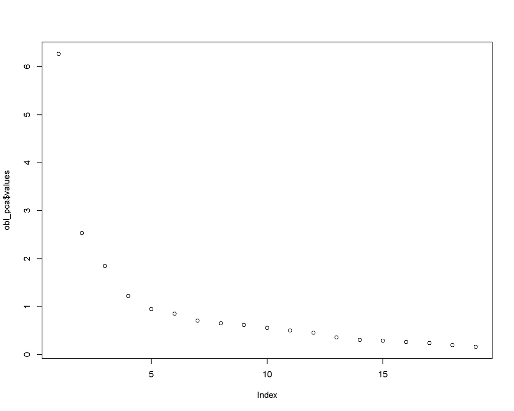

```r
plot(obl_pca$values)
```

Das zeigt uns das wir eigentlich vier Faktoren extrahieren sollten.

Dies kann folgenderweise getan werden:

```r
obl_pca_4 <- allbus2008 %>%
  select(V702:V720) %>%
  pca(nfactors = 4, rotate = "oblimin")

obl_pca_4
```

```
## Principal Components Analysis
## Call: principal(r = r, nfactors = nfactors, residuals = residuals,
##     rotate = rotate, n.obs = n.obs, covar = covar, scores = scores,
##     missing = missing, impute = impute, oblique.scores = oblique.scores,
##     method = method)
## Standardized loadings (pattern matrix) based upon correlation matrix
##        TC3   TC4   TC1   TC2   h2   u2 com
## V702  0.02  0.91 -0.03 -0.01 0.85 0.15 1.0
## V703  0.03  0.91  0.02 -0.01 0.81 0.19 1.0
## V704 -0.01  0.84 -0.07  0.01 0.77 0.23 1.0
## V705 -0.17  0.25 -0.60  0.01 0.69 0.31 1.5
## V706 -0.17  0.10 -0.59  0.17 0.50 0.50 1.4
## V707 -0.11 -0.17  0.56  0.06 0.40 0.60 1.3
## V708  0.06 -0.02 -0.59 -0.03 0.32 0.68 1.0
## V709  0.19 -0.33  0.57  0.04 0.77 0.23 1.8
## V710  0.11 -0.23  0.62  0.10 0.68 0.32 1.4
## V711 -0.33  0.17 -0.17 -0.06 0.28 0.72 2.1
## V712  0.80  0.02  0.13  0.01 0.73 0.27 1.1
## V713  0.90  0.06 -0.08  0.00 0.74 0.26 1.0
## V714  0.77  0.03  0.11  0.00 0.66 0.34 1.0
## V715  0.82 -0.04 -0.10  0.05 0.66 0.34 1.0
## V716 -0.10  0.35  0.70  0.07 0.39 0.61 1.6
## V717  0.03  0.01 -0.04  0.77 0.60 0.40 1.0
## V718 -0.03 -0.02  0.00  0.85 0.72 0.28 1.0
## V719  0.01  0.00  0.03  0.79 0.64 0.36 1.0
## V720  0.03  0.01  0.00  0.80 0.65 0.35 1.0
##
##                        TC3  TC4  TC1  TC2
## SS loadings           3.14 3.05 2.99 2.68
## Proportion Var        0.17 0.16 0.16 0.14
## Cumulative Var        0.17 0.33 0.48 0.62
## Proportion Explained  0.26 0.26 0.25 0.23
## Cumulative Proportion 0.26 0.52 0.77 1.00
##
##  With component correlations of
##       TC3   TC4   TC1   TC2
## TC3  1.00 -0.31  0.35  0.22
## TC4 -0.31  1.00 -0.44 -0.09
## TC1  0.35 -0.44  1.00  0.18
## TC2  0.22 -0.09  0.18  1.00
##
## Mean item complexity =  1.2
## Test of the hypothesis that 4 components are sufficient.
##
## The root mean square of the residuals (RMSR) is  0.06
##  with the empirical chi square  3617.09  with prob <  0
##
## Fit based upon off diagonal values = 0.97
```

### Zweite Herangehensweise

**Nutzung des `sjPlot` - Packages!**

Der Vorteil hier: die Funktion wendet automatisch das Kaiser Kriterium an (es werden nur Dimensionen > 1 Eigenvalues extrahiert).

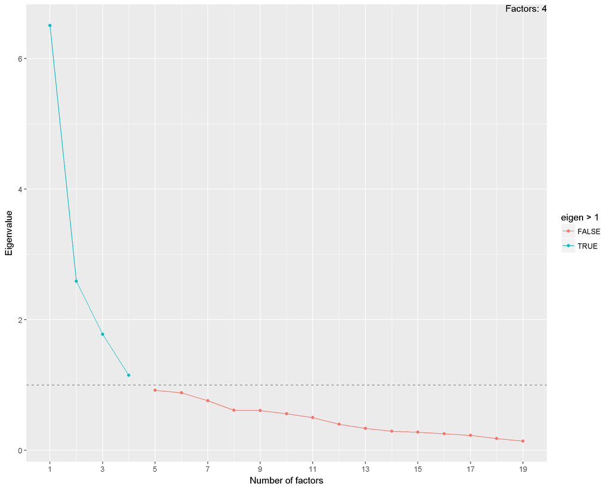

```
## Importance of components:
##                           PC1    PC2     PC3     PC4     PC5     PC6
## Standard deviation     2.5513 1.6089 1.33257 1.07206 0.95986 0.94059
## Proportion of Variance 0.3426 0.1363 0.09346 0.06049 0.04849 0.04656
## Cumulative Proportion  0.3426 0.4788 0.57229 0.63278 0.68127 0.72783
##                            PC7     PC8     PC9    PC10    PC11   PC12
## Standard deviation     0.87193 0.78550 0.78245 0.75016 0.70873 0.6332
## Proportion of Variance 0.04001 0.03247 0.03222 0.02962 0.02644 0.0211
## Cumulative Proportion  0.76784 0.80032 0.83254 0.86216 0.88859 0.9097
##                           PC13    PC14    PC15    PC16    PC17   PC18
## Standard deviation     0.57908 0.54121 0.52783 0.50380 0.47974 0.4248
## Proportion of Variance 0.01765 0.01542 0.01466 0.01336 0.01211 0.0095
## Cumulative Proportion  0.92735 0.94276 0.95743 0.97079 0.98290 0.9924
##                          PC19
## Standard deviation     0.3800
## Proportion of Variance 0.0076
## Cumulative Proportion  1.0000
##  [1] 6.5089989 2.5886795 1.7757468 1.1493067 0.9213358 0.8847084 0.7602541
##  [8] 0.6170025 0.6122276 0.5627383 0.5023048 0.4009675 0.3353371 0.2929113
## [15] 0.2786095 0.2538130 0.2301499 0.1804780 0.1444302
```

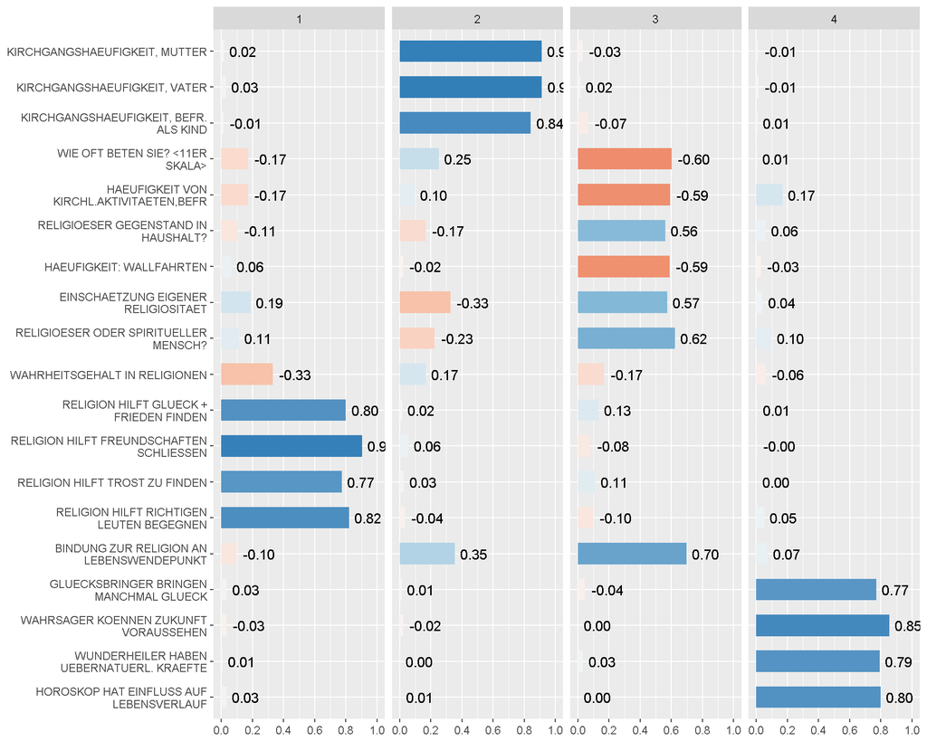

```r
sjp.pca(allbus2008 %>% select(V702:V720),
  rotation = "oblimin",  # Wähle die Rotation (ansonsten: "varimax")
  plot.eigen = T)  # Plot um die Eigenvalues anzuzeigen
```

**Eine Variation**

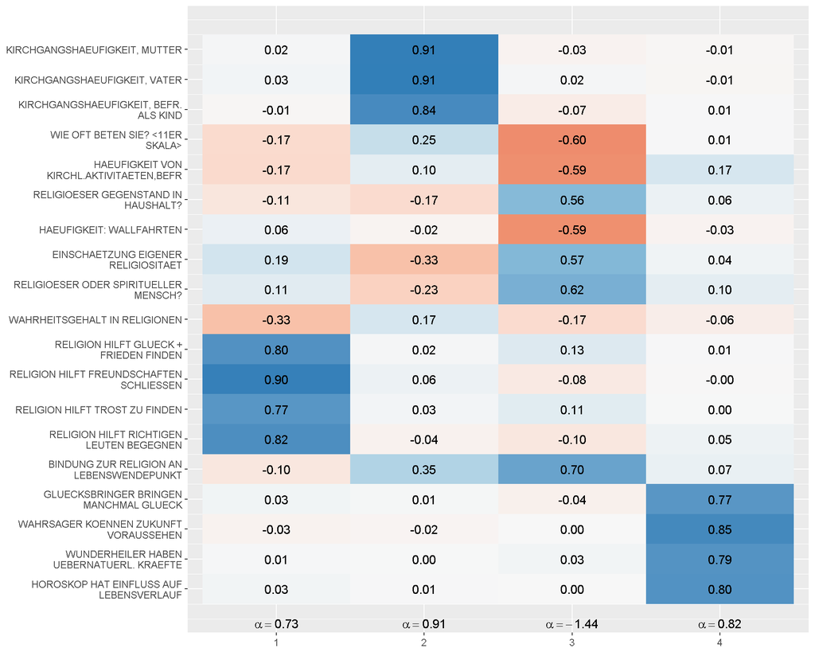

```r
sjp.pca(allbus2008 %>% select(V702:V720),
  rotation = "oblimin",
  type = "tile")
```

**Es können auch Tabellen erstellten werden**

**ACHTUNG:** Geht nur mit HTML!

```r
sjt.pca(allbus2008 %>% select(V702:V720),
  rotation = "oblimin")
```

Principal Component Analysis

|  | Component 1 | Component 2 | Component 3 | Component 4 |
| --- | --- | --- | --- | --- |
| KIRCHGANGSHAEUFIGKEIT, MUTTER | 0.02 | 0.91 | -0.03 | -0.01 |
| KIRCHGANGSHAEUFIGKEIT, VATER | 0.03 | 0.91 | 0.02 | -0.01 |
| KIRCHGANGSHAEUFIGKEIT, BEFR. ALS KIND | -0.01 | 0.84 | -0.07 | 0.01 |
| WIE OFT BETEN SIE? <11ER SKALA> | -0.17 | 0.25 | -0.60 | 0.01 |
| HAEUFIGKEIT VON KIRCHL.AKTIVITAETEN,BEFR | -0.17 | 0.10 | -0.59 | 0.17 |
| RELIGIOESER GEGENSTAND IN HAUSHALT? | -0.11 | -0.17 | 0.56 | 0.06 |
| HAEUFIGKEIT: WALLFAHRTEN | 0.06 | -0.02 | -0.59 | -0.03 |
| EINSCHAETZUNG EIGENER RELIGIOSITAET | 0.19 | -0.33 | 0.57 | 0.04 |
| RELIGIOESER ODER SPIRITUELLER MENSCH? | 0.11 | -0.23 | 0.62 | 0.10 |
| WAHRHEITSGEHALT IN RELIGIONEN | -0.33 | 0.17 | -0.17 | -0.06 |
| RELIGION HILFT GLUECK + FRIEDEN FINDEN | 0.80 | 0.02 | 0.13 | 0.01 |
| RELIGION HILFT FREUNDSCHAFTEN SCHLIESSEN | 0.90 | 0.06 | -0.08 | -0.00 |
| RELIGION HILFT TROST ZU FINDEN | 0.77 | 0.03 | 0.11 | 0.00 |
| RELIGION HILFT RICHTIGEN LEUTEN BEGEGNEN | 0.82 | -0.04 | -0.10 | 0.05 |
| BINDUNG ZUR RELIGION AN LEBENSWENDEPUNKT | -0.10 | 0.35 | 0.70 | 0.07 |
| GLUECKSBRINGER BRINGEN MANCHMAL GLUECK | 0.03 | 0.01 | -0.04 | 0.77 |
| WAHRSAGER KOENNEN ZUKUNFT VORAUSSEHEN | -0.03 | -0.02 | 0.00 | 0.85 |
| WUNDERHEILER HABEN UEBERNATUERL. KRAEFTE | 0.01 | 0.00 | 0.03 | 0.79 |
| HOROSKOP HAT EINFLUSS AUF LEBENSVERLAUF | 0.03 | 0.01 | 0.00 | 0.80 |
| Cronbach’s α | 0.73 | 0.91 | -1.44 | 0.82 |
| oblimin-rotation |  |  |  |  |